# Practice exam - Apartment applicants

ExamPA.net

04 September, 2020

```r
#NO CHANGES NEEDED
set.seed(1)
library(knitr)
library(broom)
library(ggplot2)
library(plyr)
library(corrplot)
library(caret)
library(gridExtra)
library(scales)
library(Rmisc)
library(randomForest)
library(psych)
library(xgboost)
library(rpart)
library(rpart.plot)
library(randomForest)
library(tidyverse)
library(ExamPAData)
theme_set(theme_minimal())

df <- apartment_apps
```

## Set up

Your assistant has provided you with these code templates.

```r
#This function will calculate the log-liklihood based on a Poisson model for the number of applicants
LLfunction <- function(targets, predicted_values){
  p_v_zero <- ifelse(predicted_values <= 0, 0, predicted_values)
  p_v_pos <- ifelse(predicted_values <= 0, 0.000001 ,predicted_values)
  return(sum(targets*log(p_v_pos)) - sum(p_v_zero))
}
print("loglikelihood")
LLfunction(test$applicants,predictions)
```

This code creates a scatter plot, a box plot, and a histogram.

```r
#create a boxplot
ggplot(df, aes(as.factor(applicants),VARIABLE)) +
  geom_boxplot()

#create a scatterplot
ggplot(df,aes(applicants,VARIABLE)) +
  geom_point()

#create a histogram
ggplot(df,aes(VARIABLE)) +
  geom_histogram()

#create a bar plot
ggplot(df, aes(VARIABLE)) +
  geom_bar(stat = "count")
```

Shows the average number of applicants across factor levels.

```r
#Average number of health applicants per unit
df %>%
  group_by(VARIABLE) %>%
  summarise(
    average_num_applicants = sum(applicants*num_units)/sum(num_units)
  )
```

Converts variables to numeric or factor while also setting the base reference level to the value which has the most observations.

```r
##Convert to factor and set factor levels
df <- df %>% mutate(VARIABLE = fct_infreq(as.character(VARIABLE))

#Using Base R
df$VARIABLE = fct_infreq(as.character(df$VARIABLE))

#Convert to numeric
df <- df %>% mutate(VARIABLE = fct_infreq(as.characterVARIABLE))

#Using Base R
df$VARIABLE = as.numeric(df$VARIABLE)
```

## Task 1 - Examine the target variable and number of units

```r
glimpse(df)
```

```
## Rows: 1,430
## Columns: 41
## $ applicants                 <int> 3, 5, 3, 4, 5, 5, 5, 5, 2, 3, 1, 6, 1, 5...
## $ sale_price                 <dbl> 208500, 181500, 223500, 140000, 250000, ...
## $ num_units                  <int> 4, 5, 1, 3, 5, 3, 1, 3, 5, 4, 3, 1, 5, 2...
## $ year_sold                  <int> 2008, 2007, 2008, 2011, 2008, 2009, 2007...
## $ month_sold                 <int> 2, 5, 9, 2, 12, 10, 8, 11, 4, 1, 2, 7, 9...
## $ overall_qual               <int> 7, 6, 7, 7, 8, 5, 8, 7, 7, 5, 5, 9, 5, 7...
## $ total_sq_feet              <dbl> 3586.886, 3560.348, 3672.314, 3527.523, ...
## $ gr_liv_area                <dbl> 2785.060, 2315.267, 2852.313, 2791.378, ...
## $ tot_bathrooms              <int> 5, 3, 5, 3, 5, 3, 4, 5, 3, 3, 3, 5, 3, 3...
## $ lot_area                   <dbl> 3898.256, 4149.410, 4461.603, 4139.131, ...
## $ exter_qual                 <int> 4, 3, 4, 3, 4, 3, 4, 3, 3, 3, 3, 5, 3, 4...
## $ full_bath                  <int> 4, 4, 4, 2, 4, 2, 4, 4, 4, 2, 2, 6, 2, 4...
## $ central_air                <chr> "yes", "yes", "yes", "yes", "yes", "yes"...
```

[output cut: 28 more lines]

```r
summary(df)
```

```
##    applicants      sale_price       num_units       year_sold
##  Min.   :0.000   Min.   : 34900   Min.   :1.000   Min.   :2007
##  1st Qu.:2.000   1st Qu.:129600   1st Qu.:1.000   1st Qu.:2008
##  Median :4.000   Median :163000   Median :2.000   Median :2009
##  Mean   :3.633   Mean   :181069   Mean   :2.685   Mean   :2009
##  3rd Qu.:5.000   3rd Qu.:214375   3rd Qu.:4.000   3rd Qu.:2010
##  Max.   :7.000   Max.   :755000   Max.   :5.000   Max.   :2011
##    month_sold      overall_qual    total_sq_feet   gr_liv_area
##  Min.   : 1.000   Min.   : 1.000   Min.   : 311   Min.   : 261.6
##  1st Qu.: 5.000   1st Qu.: 5.000   1st Qu.:3193   1st Qu.:2139.6
##  Median : 6.000   Median : 6.000   Median :3528   Median :2547.0
##  Mean   : 6.329   Mean   : 6.082   Mean   :3510   Mean   :2511.2
##  3rd Qu.: 8.000   3rd Qu.: 7.000   3rd Qu.:3852   3rd Qu.:2852.3
##  Max.   :12.000   Max.   :10.000   Max.   :5171   Max.   :4273.5
##  tot_bathrooms      lot_area         exter_qual     full_bath
##  Min.   :1.000   Min.   :  465.9   Min.   :2.00   Min.   :0.000
##  1st Qu.:3.000   1st Qu.: 3725.6   1st Qu.:3.00   1st Qu.:2.000
##  Median :3.000   Median : 4138.8   Median :3.00   Median :4.000
##  Mean   :2.952   Mean   : 4070.4   Mean   :3.39   Mean   :3.115
##  3rd Qu.:3.000   3rd Qu.: 4529.0   3rd Qu.:4.00   3rd Qu.:4.000
##  Max.   :8.000   Max.   :10271.5   Max.   :5.00   Max.   :6.000
##  central_air        garage_type_attchd garage_type_basment garage_type_builtIn
##  Length:1430        Min.   :0.0000     Min.   :0.00000     Min.   :0.00000
##  Class :character   1st Qu.:0.0000     1st Qu.:0.00000     1st Qu.:0.00000
##  Mode  :character   Median :1.0000     Median :0.00000     Median :0.00000
##                     Mean   :0.5888     Mean   :0.01329     Mean   :0.06084
##                     3rd Qu.:1.0000     3rd Qu.:0.00000     3rd Qu.:0.00000
##                     Max.   :1.0000     Max.   :1.00000     Max.   :1.00000
##  garage_type_detchd garage_type_no_garage NeighborhoodBrDale
##  Min.   :0.0000     Min.   :0.00000       Min.   :0.00000
##  1st Qu.:0.0000     1st Qu.:0.00000       1st Qu.:0.00000
##  Median :0.0000     Median :0.00000       Median :0.00000
##  Mean   :0.2699     Mean   :0.05664       Mean   :0.01119
##  3rd Qu.:1.0000     3rd Qu.:0.00000       3rd Qu.:0.00000
##  Max.   :1.0000     Max.   :1.00000       Max.   :1.00000
##  neighborhood_brk_side neighborhood_clear_cr neighborhood_collg_cr
##  Min.   :0.00000       Min.   :0.00000       Min.   :0.0000
##  1st Qu.:0.00000       1st Qu.:0.00000       1st Qu.:0.0000
##  Median :0.00000       Median :0.00000       Median :0.0000
##  Mean   :0.04056       Mean   :0.01958       Mean   :0.1049
```

[output cut: 36 more lines]

```
##  Max.   :1.00000       Max.   :1.00000      Max.   :1.00000
##  neighborhood_swisu neighborhood_timber neighborhood_veenker
##  Min.   :0.00000    Min.   :0.00000     Min.   :0.000000
##  1st Qu.:0.00000    1st Qu.:0.00000     1st Qu.:0.000000
##  Median :0.00000    Median :0.00000     Median :0.000000
##  Mean   :0.01748    Mean   :0.02657     Mean   :0.007692
##  3rd Qu.:0.00000    3rd Qu.:0.00000     3rd Qu.:0.000000
##  Max.   :1.00000    Max.   :1.00000     Max.   :1.000000
##  neighborhood_saleprice
##  Min.   :101389
##  1st Qu.:136902
##  Median :181841
##  Mean   :180909
##  3rd Qu.:198518
##  Max.   :331835
```

```r
sum(df$num_units)
```

```
## [1] 3839
```

```r
sum(df$num_units*df$applicants)/sum(df$num_units)
```

```
## [1] 3.588695
```

```r
df %>% summarise(avg_applicants = sum(applicants*num_units)/sum(num_units))
```

```
##   avg_applicants
## 1       3.588695
```

```r
#NO CODE CHANGES NEEDED
df %>%
  group_by(applicants) %>%
  summarise(total_units = sum(num_units))
```

```
## # A tibble: 8 x 2
##   applicants total_units
##        <int>       <int>
## 1          0         152
## 2          1         360
## 3          2         532
## 4          3         898
## 5          4         487
## 6          5        1028
## 7          6         103
## 8          7         279
```

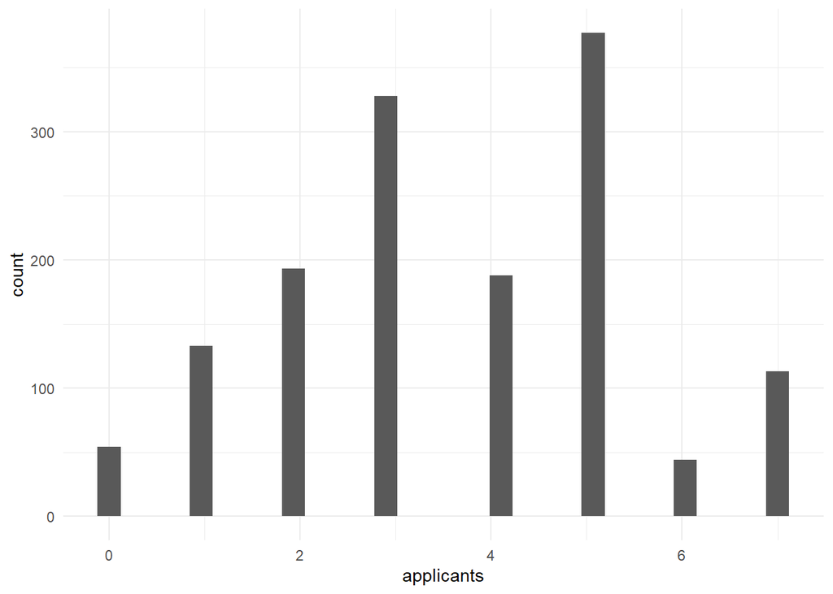

```r
#Graph A: Histogram
ggplot(data=df, aes(applicants)) +
        geom_histogram()
```

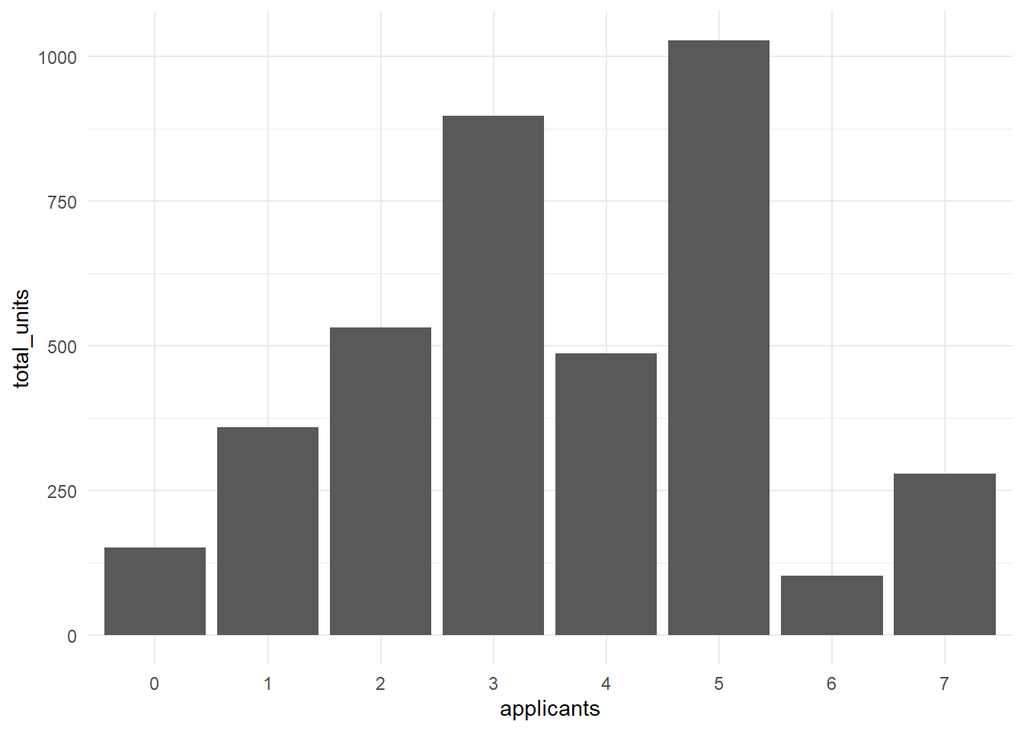

```r
#Graph B: Bar plot
df %>%
  mutate(applicants = as.factor(applicants)) %>%
  group_by(applicants) %>%
  summarise(
    total_units = sum(num_units)
  ) %>%
  ungroup() %>%
  ggplot(aes(x=applicants, y=total_units)) +
  geom_bar(stat="identity")
```

## Task 2 - Explore the predictor variables

```r
summary(df)
```

```
##    applicants      sale_price       num_units       year_sold
##  Min.   :0.000   Min.   : 34900   Min.   :1.000   Min.   :2007
##  1st Qu.:2.000   1st Qu.:129600   1st Qu.:1.000   1st Qu.:2008
##  Median :4.000   Median :163000   Median :2.000   Median :2009
##  Mean   :3.633   Mean   :181069   Mean   :2.685   Mean   :2009
##  3rd Qu.:5.000   3rd Qu.:214375   3rd Qu.:4.000   3rd Qu.:2010
##  Max.   :7.000   Max.   :755000   Max.   :5.000   Max.   :2011
##    month_sold      overall_qual    total_sq_feet   gr_liv_area
##  Min.   : 1.000   Min.   : 1.000   Min.   : 311   Min.   : 261.6
##  1st Qu.: 5.000   1st Qu.: 5.000   1st Qu.:3193   1st Qu.:2139.6
##  Median : 6.000   Median : 6.000   Median :3528   Median :2547.0
##  Mean   : 6.329   Mean   : 6.082   Mean   :3510   Mean   :2511.2
##  3rd Qu.: 8.000   3rd Qu.: 7.000   3rd Qu.:3852   3rd Qu.:2852.3
##  Max.   :12.000   Max.   :10.000   Max.   :5171   Max.   :4273.5
##  tot_bathrooms      lot_area         exter_qual     full_bath
##  Min.   :1.000   Min.   :  465.9   Min.   :2.00   Min.   :0.000
##  1st Qu.:3.000   1st Qu.: 3725.6   1st Qu.:3.00   1st Qu.:2.000
##  Median :3.000   Median : 4138.8   Median :3.00   Median :4.000
##  Mean   :2.952   Mean   : 4070.4   Mean   :3.39   Mean   :3.115
##  3rd Qu.:3.000   3rd Qu.: 4529.0   3rd Qu.:4.00   3rd Qu.:4.000
##  Max.   :8.000   Max.   :10271.5   Max.   :5.00   Max.   :6.000
##  central_air        garage_type_attchd garage_type_basment garage_type_builtIn
##  Length:1430        Min.   :0.0000     Min.   :0.00000     Min.   :0.00000
##  Class :character   1st Qu.:0.0000     1st Qu.:0.00000     1st Qu.:0.00000
##  Mode  :character   Median :1.0000     Median :0.00000     Median :0.00000
##                     Mean   :0.5888     Mean   :0.01329     Mean   :0.06084
##                     3rd Qu.:1.0000     3rd Qu.:0.00000     3rd Qu.:0.00000
##                     Max.   :1.0000     Max.   :1.00000     Max.   :1.00000
##  garage_type_detchd garage_type_no_garage NeighborhoodBrDale
##  Min.   :0.0000     Min.   :0.00000       Min.   :0.00000
##  1st Qu.:0.0000     1st Qu.:0.00000       1st Qu.:0.00000
##  Median :0.0000     Median :0.00000       Median :0.00000
##  Mean   :0.2699     Mean   :0.05664       Mean   :0.01119
##  3rd Qu.:1.0000     3rd Qu.:0.00000       3rd Qu.:0.00000
##  Max.   :1.0000     Max.   :1.00000       Max.   :1.00000
##  neighborhood_brk_side neighborhood_clear_cr neighborhood_collg_cr
##  Min.   :0.00000       Min.   :0.00000       Min.   :0.0000
##  1st Qu.:0.00000       1st Qu.:0.00000       1st Qu.:0.0000
##  Median :0.00000       Median :0.00000       Median :0.0000
##  Mean   :0.04056       Mean   :0.01958       Mean   :0.1049
```

[output cut: 36 more lines]

```
##  Max.   :1.00000       Max.   :1.00000      Max.   :1.00000
##  neighborhood_swisu neighborhood_timber neighborhood_veenker
##  Min.   :0.00000    Min.   :0.00000     Min.   :0.000000
##  1st Qu.:0.00000    1st Qu.:0.00000     1st Qu.:0.000000
##  Median :0.00000    Median :0.00000     Median :0.000000
##  Mean   :0.01748    Mean   :0.02657     Mean   :0.007692
##  3rd Qu.:0.00000    3rd Qu.:0.00000     3rd Qu.:0.000000
##  Max.   :1.00000    Max.   :1.00000     Max.   :1.000000
##  neighborhood_saleprice
##  Min.   :101389
##  1st Qu.:136902
##  Median :181841
##  Mean   :180909
##  3rd Qu.:198518
##  Max.   :331835
```

```r
#NO CHANGES NEEDED
#Calculate weighted averages with num_units as the weights
df %>%
  summarise(
    mean_number_of_units = sum(num_units),
    mean_sale_price = dollar(sum(num_units*sale_price)/sum(num_units)),
    mean_overall_qual = sum(num_units*overall_qual)/sum(num_units)
  )
```

```
##   mean_number_of_units mean_sale_price mean_overall_qual
## 1                 3839        $180,146          6.060172
```

```r
#neighborhood sale price
df %>% arrange(desc(neighborhood_saleprice)) %>% head()
```

```
##   applicants sale_price num_units year_sold month_sold overall_qual
## 1          5     250000         5      2008         12            8
## 2          5     260000         1      2011          4            8
## 3          5     290000         5      2007          6            7
## 4          7     403000         5      2009          7            8
## 5          5     290000         1      2010          4            8
## 6          5     260000         5      2009          4            7
##   total_sq_feet gr_liv_area tot_bathrooms lot_area exter_qual full_bath
## 1      4012.276    3173.357             5 4928.292          4         4
## 2      4177.628    3320.271             3 5162.163          4         4
## 3      4185.423    3384.823             3 4219.896          4         4
## 4      4400.613    3544.485             5 5045.905          4         4
## 5      4049.839    3223.213             3 4549.542          4         4
## 6      4298.024    3460.295             5 4209.979          4         4
##   central_air garage_type_attchd garage_type_basment garage_type_builtIn
```

[output cut: 69 more lines]

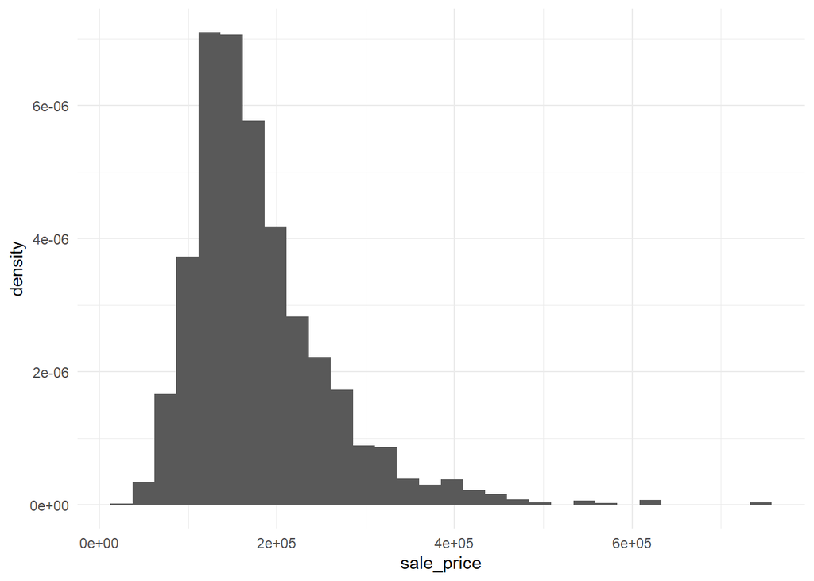

```r
#Sale Price
df %>%
  ggplot(aes(sale_price,y=..density.., weight = num_units)) +
  geom_histogram()
```

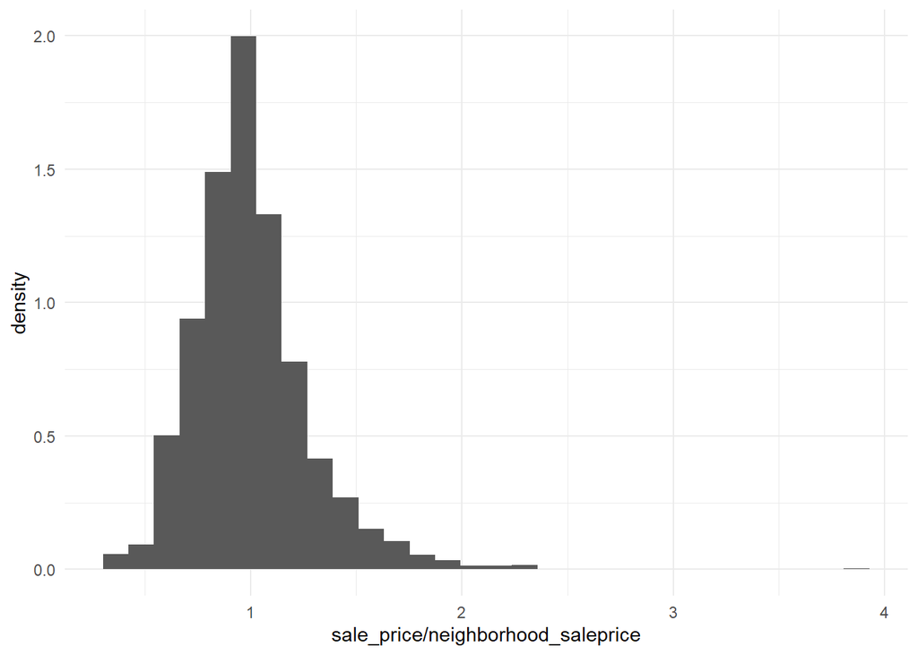

```r
df %>%
  ggplot(aes(sale_price/neighborhood_saleprice,y=..density.., weight = num_units)) +
  geom_histogram()
```

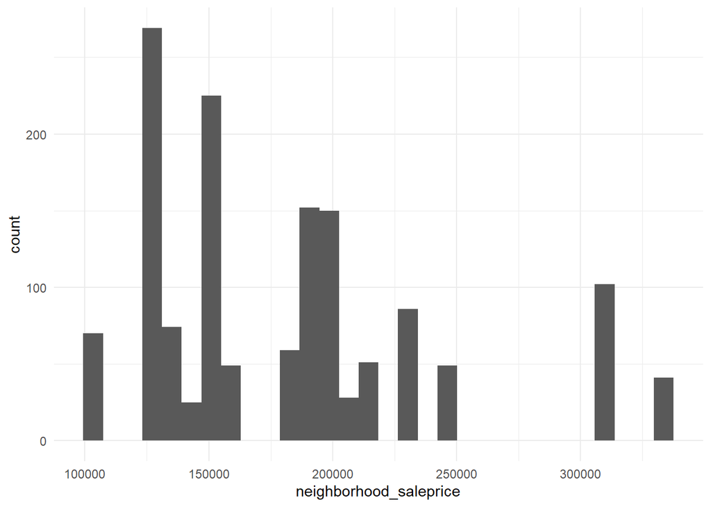

```r
df %>%
  ggplot(aes(neighborhood_saleprice)) +
  geom_histogram()
```

```r
df <- df %>% mutate(log_rel_price = log(sale_price/neighborhood_saleprice),
                    log_sale_price = log(sale_price)) %>%
  dplyr::select(-sale_price, -neighborhood_saleprice)
```

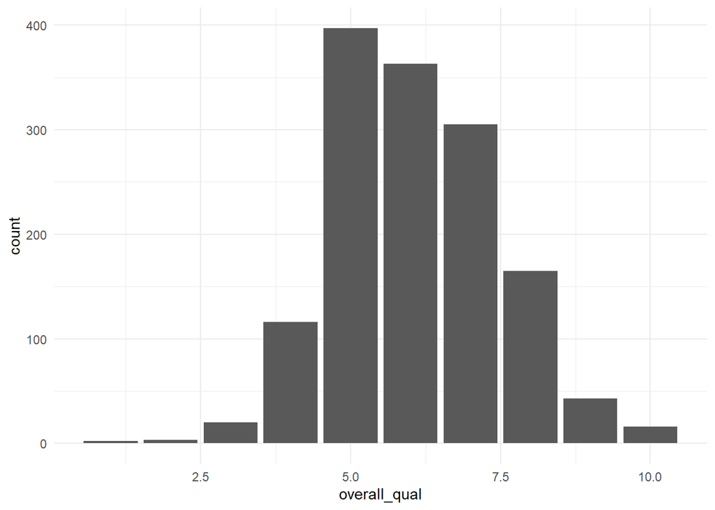

```r
#overall qual
ggplot(df,aes(overall_qual)) +
  geom_bar(stat = "count")
```

```r
df %>%
  summarise(
    avg = sum(num_units*overall_qual)/sum(num_units)
  )
```

```
##        avg
## 1 6.060172
```

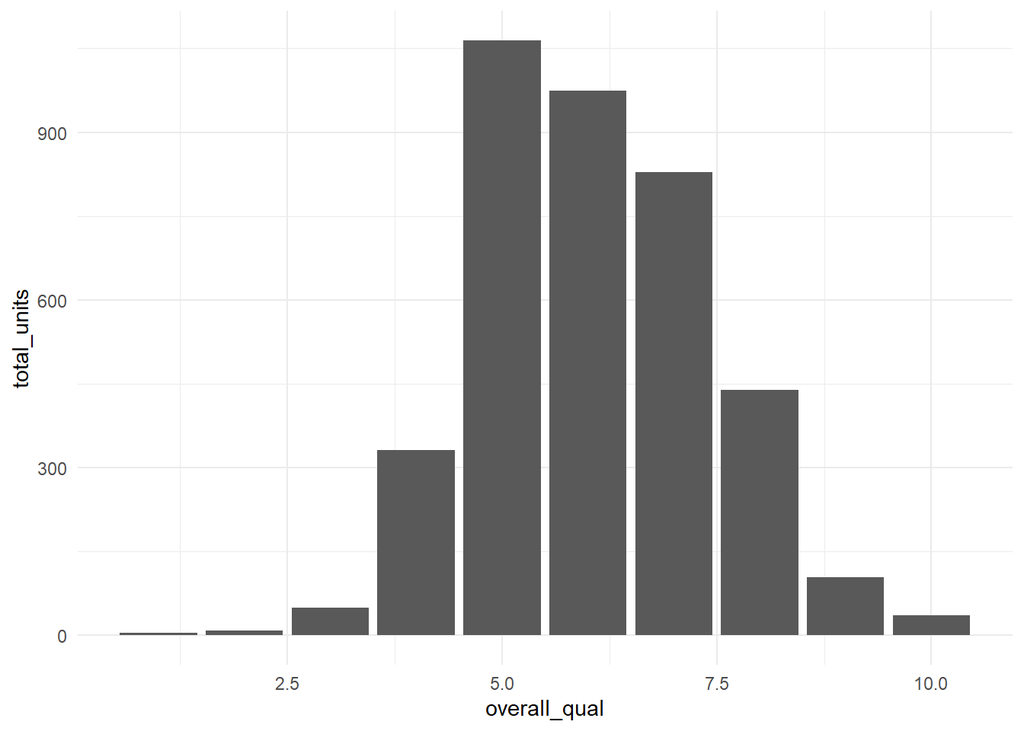

```r
df %>%
  group_by(overall_qual) %>%
  summarise(
    total_units = sum(num_units)
  ) %>%
  ggplot(aes(x=overall_qual, y=total_units)) +
  geom_bar(stat="identity")
```

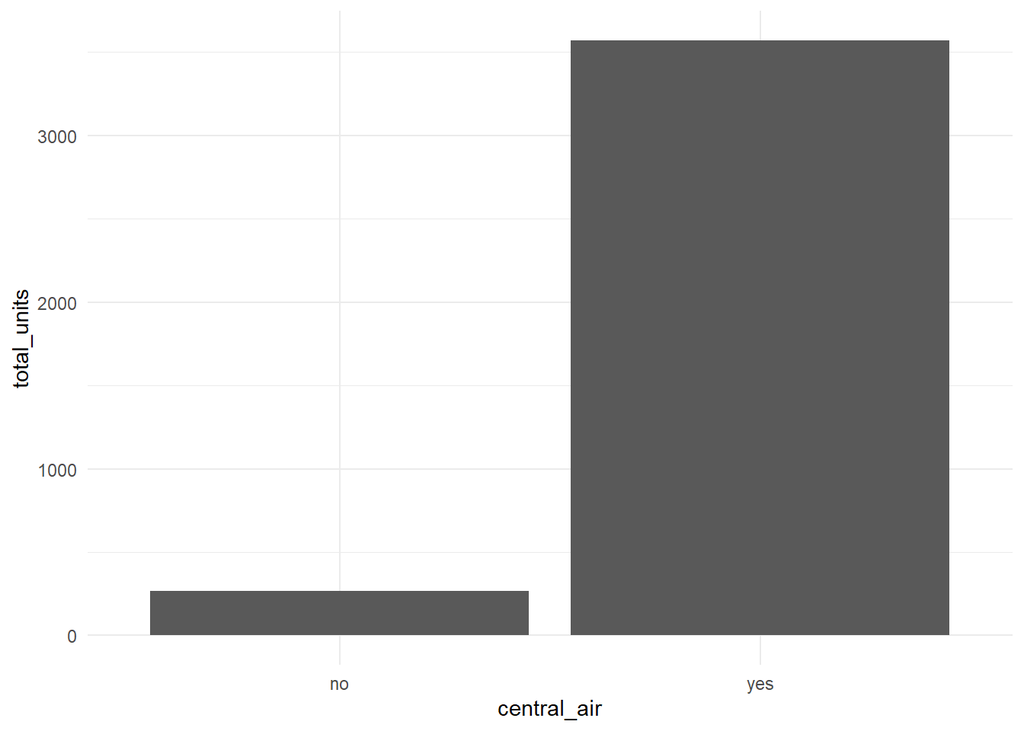

```r
#central air

df %>%
  group_by(central_air) %>%
  summarise(
    total_units = sum(num_units)
  ) %>%
  ggplot(aes(x=central_air, y=total_units)) +
  geom_bar(stat="identity")
```

```r
df %>%
  group_by(central_air) %>%
  summarise(
    total_units = sum(num_units)
  )
```

```
## # A tibble: 2 x 2
##   central_air total_units
##   <chr>             <int>
## 1 no                  269
## 2 yes                3570
```

```r
df %>% count(overall_qual)
```

```
##    overall_qual   n
## 1             1   2
## 2             2   3
## 3             3  20
## 4             4 116
## 5             5 397
## 6             6 363
## 7             7 305
## 8             8 165
## 9             9  43
## 10           10  16
```

```r
#check that bae level (the one that appears first) is the one with the most observations
summary(df$central_air)
```

```
##    Length     Class      Mode
##      1430 character character
```

```r
df %>% group_by(central_air) %>%
  summarise(applicants=sum(applicants),
            total_units = sum(num_units))
```

```
## # A tibble: 2 x 3
##   central_air applicants total_units
##   <chr>            <int>       <int>
## 1 no                  54         269
## 2 yes               5141        3570
```

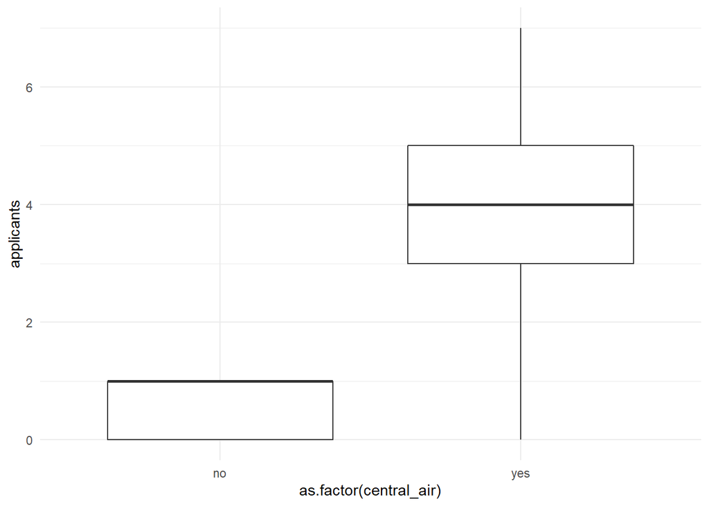

```r
ggplot(df,aes(as.factor(central_air),applicants)) +
  geom_boxplot()
```

```r
df$central_air <- fct_infreq(df$central_air)
summary(df$central_air)
```

```
##  yes   no
## 1335   95
```

## Task 3 - Engineer three additional features

```r
df <- df %>%
  mutate(
    sale_price_per_sqft = exp(log_rel_price) / total_sq_feet,
    bath_pr_sqft = tot_bathrooms/total_sq_feet,
    student_apt = ifelse(month_sold %in% c(7,8),1,0)
  )
df %>% count(student_apt)
```

```
##   student_apt    n
## 1           0 1079
## 2           1  351
```

```r
df %>% summary()
```

```
##    applicants      num_units       year_sold      month_sold
##  Min.   :0.000   Min.   :1.000   Min.   :2007   Min.   : 1.000
##  1st Qu.:2.000   1st Qu.:1.000   1st Qu.:2008   1st Qu.: 5.000
##  Median :4.000   Median :2.000   Median :2009   Median : 6.000
##  Mean   :3.633   Mean   :2.685   Mean   :2009   Mean   : 6.329
##  3rd Qu.:5.000   3rd Qu.:4.000   3rd Qu.:2010   3rd Qu.: 8.000
##  Max.   :7.000   Max.   :5.000   Max.   :2011   Max.   :12.000
##   overall_qual    total_sq_feet   gr_liv_area     tot_bathrooms
##  Min.   : 1.000   Min.   : 311   Min.   : 261.6   Min.   :1.000
##  1st Qu.: 5.000   1st Qu.:3193   1st Qu.:2139.6   1st Qu.:3.000
##  Median : 6.000   Median :3528   Median :2547.0   Median :3.000
##  Mean   : 6.082   Mean   :3510   Mean   :2511.2   Mean   :2.952
##  3rd Qu.: 7.000   3rd Qu.:3852   3rd Qu.:2852.3   3rd Qu.:3.000
##  Max.   :10.000   Max.   :5171   Max.   :4273.5   Max.   :8.000
##     lot_area         exter_qual     full_bath     central_air
##  Min.   :  465.9   Min.   :2.00   Min.   :0.000   yes:1335
##  1st Qu.: 3725.6   1st Qu.:3.00   1st Qu.:2.000   no :  95
##  Median : 4138.8   Median :3.00   Median :4.000
##  Mean   : 4070.4   Mean   :3.39   Mean   :3.115
##  3rd Qu.: 4529.0   3rd Qu.:4.00   3rd Qu.:4.000
##  Max.   :10271.5   Max.   :5.00   Max.   :6.000
##  garage_type_attchd garage_type_basment garage_type_builtIn garage_type_detchd
##  Min.   :0.0000     Min.   :0.00000     Min.   :0.00000     Min.   :0.0000
##  1st Qu.:0.0000     1st Qu.:0.00000     1st Qu.:0.00000     1st Qu.:0.0000
##  Median :1.0000     Median :0.00000     Median :0.00000     Median :0.0000
##  Mean   :0.5888     Mean   :0.01329     Mean   :0.06084     Mean   :0.2699
##  3rd Qu.:1.0000     3rd Qu.:0.00000     3rd Qu.:0.00000     3rd Qu.:1.0000
##  Max.   :1.0000     Max.   :1.00000     Max.   :1.00000     Max.   :1.0000
##  garage_type_no_garage NeighborhoodBrDale neighborhood_brk_side
##  Min.   :0.00000       Min.   :0.00000    Min.   :0.00000
##  1st Qu.:0.00000       1st Qu.:0.00000    1st Qu.:0.00000
##  Median :0.00000       Median :0.00000    Median :0.00000
##  Mean   :0.05664       Mean   :0.01119    Mean   :0.04056
##  3rd Qu.:0.00000       3rd Qu.:0.00000    3rd Qu.:0.00000
##  Max.   :1.00000       Max.   :1.00000    Max.   :1.00000
##  neighborhood_clear_cr neighborhood_collg_cr neighborhood_crawfor
##  Min.   :0.00000       Min.   :0.0000        Min.   :0.00000
##  1st Qu.:0.00000       1st Qu.:0.0000        1st Qu.:0.00000
##  Median :0.00000       Median :0.0000        Median :0.00000
##  Mean   :0.01958       Mean   :0.1049        Mean   :0.03566
```

[output cut: 36 more lines]

```
##  Max.   :1.00000      Max.   :1.00000       Max.   :1.00000
##  neighborhood_timber neighborhood_veenker log_rel_price      log_sale_price
##  Min.   :0.00000     Min.   :0.000000     Min.   :-1.19109   Min.   :10.46
##  1st Qu.:0.00000     1st Qu.:0.000000     1st Qu.:-0.18330   1st Qu.:11.77
##  Median :0.00000     Median :0.000000     Median :-0.03704   Median :12.00
##  Mean   :0.02657     Mean   :0.007692     Mean   :-0.03482   Mean   :12.02
##  3rd Qu.:0.00000     3rd Qu.:0.000000     3rd Qu.: 0.11353   3rd Qu.:12.28
##  Max.   :1.00000     Max.   :1.000000     Max.   : 1.33727   Max.   :13.53
##  sale_price_per_sqft  bath_pr_sqft        student_apt
##  Min.   :0.0001087   Min.   :0.0002562   Min.   :0.0000
##  1st Qu.:0.0002471   1st Qu.:0.0006980   1st Qu.:0.0000
##  Median :0.0002804   Median :0.0008476   Median :0.0000
##  Mean   :0.0002850   Mean   :0.0008319   Mean   :0.2455
##  3rd Qu.:0.0003160   3rd Qu.:0.0010070   3rd Qu.:0.0000
##  Max.   :0.0009952   Max.   :0.0032157   Max.   :1.0000
```

## Task 4 - Inspect the garage_type variables

No code is provided.

```r
df %>% filter(
  (garage_type_attchd + garage_type_basment + garage_type_detchd + garage_type_builtIn + garage_type_no_garage) > 0)
```

[output not shown]

[output cut: 16977 more lines]

```r
#rows_with_errors <- (df$garage_type_attchd==0) + (df$garage_type_detchd==0) + (df$garage_type_builtIn==0) + (df$garage_type_no_garage==0)

#df <- df[-rows_with_errors]
```

No changes are needed to the below code. It is included because the results may be helpful for subsequent tasks.

```r
#NO CHANGES NEEDED
#Example: the 18th property has 0's for all garage type variables
df %>% dplyr::select(contains("garage")) %>%  dplyr::slice(18)
```

```
##   garage_type_attchd garage_type_basment garage_type_builtIn garage_type_detchd
## 1                  0                   0                   0                  0
##   garage_type_no_garage
## 1                     0
```

```r
#NO CHANGES NEEDED
#Calculate the Number of Units for each garage type
df %>% dplyr::select(num_units,contains("garage")) %>% gather(feature,value,-num_units) %>% group_by(feature) %>%  summarise(total_units=sum(num_units*value))
```

```
## # A tibble: 5 x 2
##   feature               total_units
##   <chr>                       <int>
## 1 garage_type_attchd           2227
## 2 garage_type_basment            55
## 3 garage_type_builtIn           235
## 4 garage_type_detchd           1052
## 5 garage_type_no_garage         226
```

```r
#NO CHANGES NEEDED
#Calculate the Number of Units for each neighborhood
df %>% dplyr::select(num_units,contains("neighborhood")) %>% gather(feature,value,-num_units) %>% group_by(feature) %>%  summarise(total_units=sum(num_units*value))
```

```
## # A tibble: 22 x 2
##    feature               total_units
##    <chr>                       <int>
##  1 neighborhood_brk_side         170
##  2 neighborhood_clear_cr          72
##  3 neighborhood_collg_cr         390
##  4 neighborhood_crawfor          137
##  5 neighborhood_edwards          259
##  6 neighborhood_gilbert          204
##  7 neighborhood_idottrr          112
##  8 neighborhood_meadowv           48
##  9 neighborhood_mitchel          141
## 10 neighborhood_n_ames           585
## # ... with 12 more rows
```

You do not need to check the neighborhood columns as your assistent has already verified that these are correct for all properties.

## Task 5 - Select GLM parameters

No code is provided

## Task 6 - Fit a GLM

```r
#NO CHANGES NEEDED
#Create training and test sets
index <- createDataPartition(y = df$applicants, p = 0.8, list = F)

train <- df %>% dplyr::slice(index)
test <- df %>% dplyr::slice(-index)

train_x <- train[,-1]
train_y <- train$applicants

#standardize to be between 0 and 1
train_number_of_units <- train$num_units/sum(train$num_units)

test_x <- test[,-1]
test_y <- test$applicants

#standardize to be between 0 and 1
test_number_of_units <- test$num_units/sum(test$num_units)
```

```r
#the base (reference) level for neighborhood is the one with the most observations
#the base (reference) level for garage is the one with the most observations

#Fit a GLM
#Do not use the offset or weight variables as predictors.  Remove them from the formula (as the below is doing)
#Type ?family into the R console to see options for FAMILY
glm <- glm(
  applicants ~ . + offset(log(num_units)) - neighborhood_n_ames - garage_type_attchd - num_units - log_sale_price,
  data = train,
  family = poisson(link = "log")
)
AIC(glm)
```

```
## [1] 5227.324
```

```r
summary(glm)
```

```
##
## Call:
## glm(formula = applicants ~ . + offset(log(num_units)) - neighborhood_n_ames -
##     garage_type_attchd - num_units - log_sale_price, family = poisson(link = "log"),
##     data = train)
##
## Deviance Residuals:
##     Min       1Q   Median       3Q      Max
## -2.4293  -0.8566   0.1287   1.1496   3.0122
##
## Coefficients:
##                              Estimate Std. Error z value Pr(>|z|)
## (Intercept)                 4.356e+00  2.188e+01   0.199 0.842205
## year_sold                  -3.047e-03  1.088e-02  -0.280 0.779500
## month_sold                 -7.767e-03  6.157e-03  -1.262 0.207125
## overall_qual               -4.255e-02  2.481e-02  -1.715 0.086373 .
## total_sq_feet               6.059e-04  1.234e-04   4.911 9.05e-07 ***
## gr_liv_area                -2.193e-05  7.950e-05  -0.276 0.782712
## tot_bathrooms              -2.928e-01  1.062e-01  -2.758 0.005819 **
## lot_area                    6.564e-06  2.362e-05   0.278 0.781081
## exter_qual                  1.632e-01  4.573e-02   3.568 0.000360 ***
## full_bath                   1.113e-02  2.491e-02   0.447 0.655090
## central_airno              -1.766e+00  1.614e-01 -10.945  < 2e-16 ***
## garage_type_basment        -6.426e-01  1.789e-01  -3.592 0.000328 ***
## garage_type_builtIn        -2.766e-01  7.494e-02  -3.692 0.000223 ***
## garage_type_detchd         -3.303e-01  5.150e-02  -6.414 1.42e-10 ***
## garage_type_no_garage      -3.811e-01  9.630e-02  -3.957 7.58e-05 ***
## NeighborhoodBrDale         -5.007e-01  2.537e-01  -1.973 0.048461 *
## neighborhood_brk_side      -2.126e-01  1.138e-01  -1.868 0.061764 .
## neighborhood_clear_cr      -1.340e-02  1.173e-01  -0.114 0.909066
## neighborhood_collg_cr      -5.164e-02  7.336e-02  -0.704 0.481500
## neighborhood_crawfor       -7.896e-02  1.051e-01  -0.751 0.452491
## neighborhood_edwards        5.394e-02  8.501e-02   0.635 0.525736
## neighborhood_gilbert        4.485e-02  8.613e-02   0.521 0.602574
## neighborhood_idottrr       -8.867e-01  2.065e-01  -4.294 1.76e-05 ***
## neighborhood_meadowv       -3.393e-01  1.991e-01  -1.704 0.088460 .
## neighborhood_mitchel       -1.210e-01  9.531e-02  -1.270 0.204195
## neighborhood_n_ridge       -2.166e-01  1.245e-01  -1.739 0.081956 .
## neighborhood_n_ridge_hghts -2.773e-01  1.124e-01  -2.468 0.013590 *
## neighborhood_n_w_ames      -6.097e-02  8.190e-02  -0.744 0.456603
## neighborhood_old_town      -5.855e-02  8.683e-02  -0.674 0.500084
## neighborhood_sawyer        -4.199e-01  9.936e-02  -4.226 2.38e-05 ***
## neighborhood_sawyer_w      -2.838e-02  8.591e-02  -0.330 0.741113
## neighborhood_somerst        2.425e-02  9.549e-02   0.254 0.799501
## neighborhood_stone_br      -7.647e-02  1.444e-01  -0.529 0.596483
## neighborhood_swisu          2.489e-01  1.503e-01   1.656 0.097665 .
## neighborhood_timber        -1.208e-01  1.183e-01  -1.021 0.307045
## neighborhood_veenker       -2.676e-01  1.927e-01  -1.389 0.164800
## log_rel_price              -7.220e-01  3.293e-01  -2.192 0.028364 *
## sale_price_per_sqft        -1.203e+03  1.114e+03  -1.080 0.280338
## bath_pr_sqft                1.147e+03  3.632e+02   3.157 0.001597 **
## student_apt                 5.005e-01  3.450e-02  14.505  < 2e-16 ***
## ---
## Signif. codes:  0 '***' 0.001 '**' 0.01 '*' 0.05 '.' 0.1 ' ' 1
##
## (Dispersion parameter for poisson family taken to be 1)
##
##     Null deviance: 2784.1  on 1144  degrees of freedom
## Residual deviance: 1723.1  on 1105  degrees of freedom
## AIC: 5227.3
##
## Number of Fisher Scoring iterations: 5
```

## Task 7 - Use AIC to select features

```r
#NO CODE CHANGES NEEDED
#The following code will use the same formula and family from the `glm` object to perform stepwise selection

library(MASS)
stepwise_result <- stepAIC(glm)
```

```
## Start:  AIC=5227.32
## applicants ~ num_units + year_sold + month_sold + overall_qual +
##     total_sq_feet + gr_liv_area + tot_bathrooms + lot_area +
##     exter_qual + full_bath + central_air + garage_type_attchd +
##     garage_type_basment + garage_type_builtIn + garage_type_detchd +
##     garage_type_no_garage + NeighborhoodBrDale + neighborhood_brk_side +
##     neighborhood_clear_cr + neighborhood_collg_cr + neighborhood_crawfor +
##     neighborhood_edwards + neighborhood_gilbert + neighborhood_idottrr +
##     neighborhood_meadowv + neighborhood_mitchel + neighborhood_n_ames +
##     neighborhood_n_ridge + neighborhood_n_ridge_hghts + neighborhood_n_w_ames +
##     neighborhood_old_town + neighborhood_sawyer + neighborhood_sawyer_w +
##     neighborhood_somerst + neighborhood_stone_br + neighborhood_swisu +
##     neighborhood_timber + neighborhood_veenker + log_rel_price +
##     log_sale_price + sale_price_per_sqft + bath_pr_sqft + student_apt +
##     offset(log(num_units)) - neighborhood_n_ames - garage_type_attchd -
##     num_units - log_sale_price
##
##                              Df Deviance    AIC
## - neighborhood_clear_cr       1   1723.1 5225.3
## - neighborhood_somerst        1   1723.2 5225.4
## - gr_liv_area                 1   1723.2 5225.4
## - lot_area                    1   1723.2 5225.4
## - year_sold                   1   1723.2 5225.4
## - neighborhood_sawyer_w       1   1723.2 5225.4
## - full_bath                   1   1723.3 5225.5
## - neighborhood_gilbert        1   1723.4 5225.6
## - neighborhood_stone_br       1   1723.4 5225.6
## - neighborhood_edwards        1   1723.5 5225.7
## - neighborhood_old_town       1   1723.6 5225.8
## - neighborhood_collg_cr       1   1723.6 5225.8
## - neighborhood_n_w_ames       1   1723.7 5225.9
## - neighborhood_crawfor        1   1723.7 5225.9
## - neighborhood_timber         1   1724.2 5226.4
## - sale_price_per_sqft         1   1724.3 5226.5
## - month_sold                  1   1724.7 5226.9
## - neighborhood_mitchel        1   1724.8 5227.0
## <none>                            1723.1 5227.3
## - neighborhood_veenker        1   1725.2 5227.4
## - neighborhood_swisu          1   1725.7 5227.9
## - overall_qual                1   1726.0 5228.3
```

[output cut: 794 more lines]

```
## - overall_qual                1   1739.2 5205.5
## - tot_bathrooms               1   1740.9 5207.2
## - bath_pr_sqft                1   1743.5 5209.7
## - neighborhood_n_ridge_hghts  1   1743.8 5210.0
## - garage_type_basment         1   1750.4 5216.6
## - exter_qual                  1   1750.8 5217.0
## - garage_type_no_garage       1   1751.8 5218.0
## - garage_type_builtIn         1   1751.8 5218.1
## - neighborhood_sawyer         1   1753.3 5219.5
## - neighborhood_idottrr        1   1759.2 5225.4
## - total_sq_feet               1   1771.7 5237.9
## - garage_type_detchd          1   1784.8 5251.0
## - log_rel_price               1   1865.1 5331.3
## - student_apt                 1   1938.4 5404.6
## - central_air                 1   1957.4 5423.6
```

```r
library(dplyr)

final_glm <- glm(
  stepwise_result$formula,
  data = train,
  family = glm$family
)

AIC(final_glm)
```

```
## [1] 5201.853
```

```r
summary(final_glm)
```

```
##
## Call:
## glm(formula = stepwise_result$formula, family = glm$family, data = train)
##
## Deviance Residuals:
##      Min        1Q    Median        3Q       Max
## -2.45272  -0.85876   0.09374   1.16514   2.98957
##
## Coefficients:
##                              Estimate Std. Error z value Pr(>|z|)
## (Intercept)                -2.204e+00  3.169e-01  -6.954 3.56e-12 ***
## overall_qual               -4.969e-02  2.097e-02  -2.370 0.017796 *
## total_sq_feet               6.171e-04  9.125e-05   6.763 1.35e-11 ***
## tot_bathrooms              -2.304e-01  7.609e-02  -3.028 0.002458 **
## exter_qual                  1.693e-01  4.075e-02   4.155 3.26e-05 ***
## central_airno              -1.795e+00  1.586e-01 -11.323  < 2e-16 ***
## garage_type_basment        -6.484e-01  1.754e-01  -3.696 0.000219 ***
## garage_type_builtIn        -2.931e-01  7.125e-02  -4.114 3.88e-05 ***
## garage_type_detchd         -3.292e-01  4.694e-02  -7.015 2.31e-12 ***
## garage_type_no_garage      -3.734e-01  9.121e-02  -4.094 4.25e-05 ***
## NeighborhoodBrDale         -5.129e-01  2.397e-01  -2.140 0.032330 *
## neighborhood_brk_side      -2.195e-01  1.056e-01  -2.079 0.037593 *
## neighborhood_gilbert        9.716e-02  6.372e-02   1.525 0.127311
## neighborhood_idottrr       -8.888e-01  2.015e-01  -4.410 1.03e-05 ***
## neighborhood_meadowv       -3.486e-01  1.826e-01  -1.910 0.056165 .
## neighborhood_n_ridge       -1.761e-01  8.602e-02  -2.047 0.040623 *
## neighborhood_n_ridge_hghts -2.253e-01  7.154e-02  -3.149 0.001636 **
## neighborhood_sawyer        -3.952e-01  9.406e-02  -4.201 2.65e-05 ***
## neighborhood_swisu          2.797e-01  1.426e-01   1.962 0.049760 *
## log_rel_price              -1.001e+00  8.683e-02 -11.528  < 2e-16 ***
## bath_pr_sqft                9.274e+02  2.543e+02   3.647 0.000266 ***
## student_apt                 4.894e-01  3.327e-02  14.712  < 2e-16 ***
## ---
## Signif. codes:  0 '***' 0.001 '**' 0.01 '*' 0.05 '.' 0.1 ' ' 1
##
## (Dispersion parameter for poisson family taken to be 1)
##
##     Null deviance: 2784.1  on 1144  degrees of freedom
## Residual deviance: 1733.6  on 1123  degrees of freedom
## AIC: 5201.9
##
## Number of Fisher Scoring iterations: 5
```

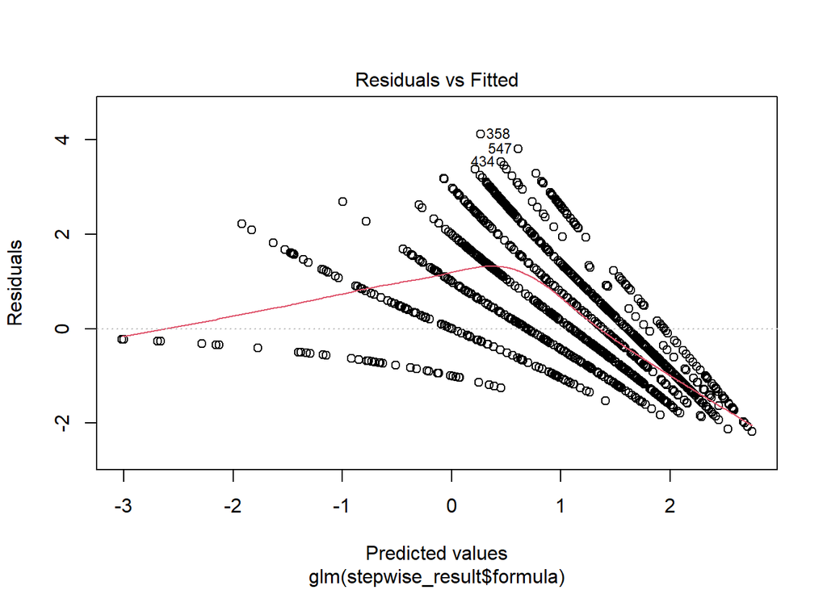

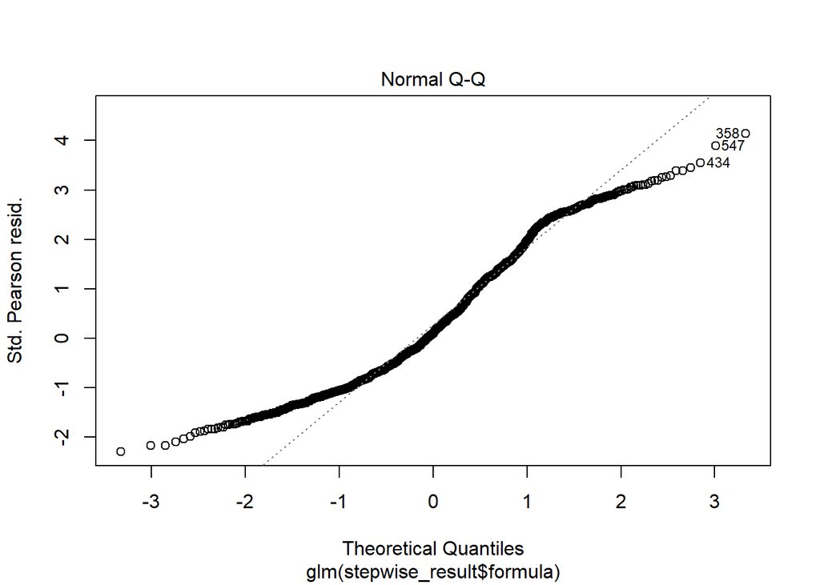

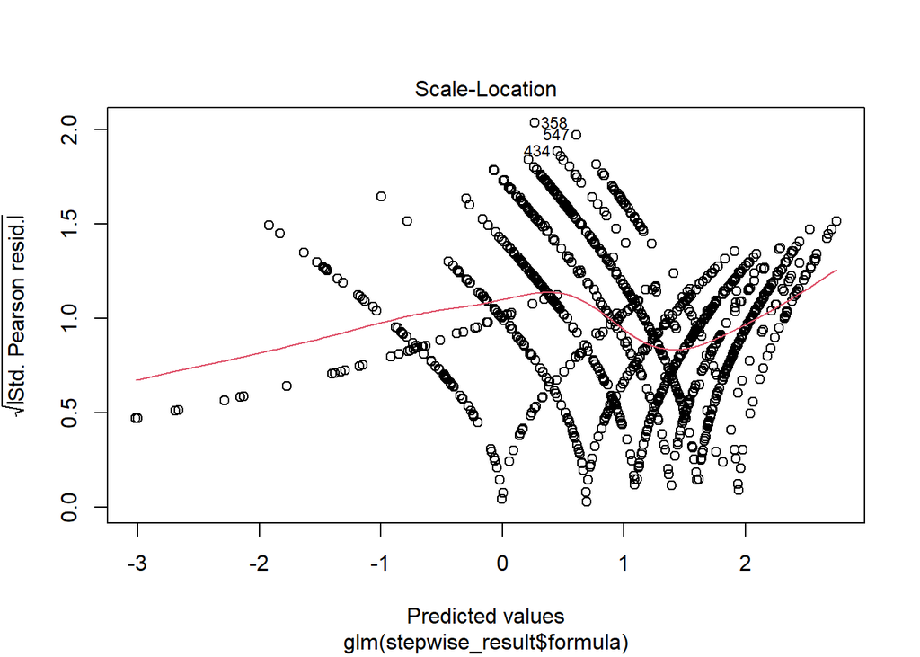

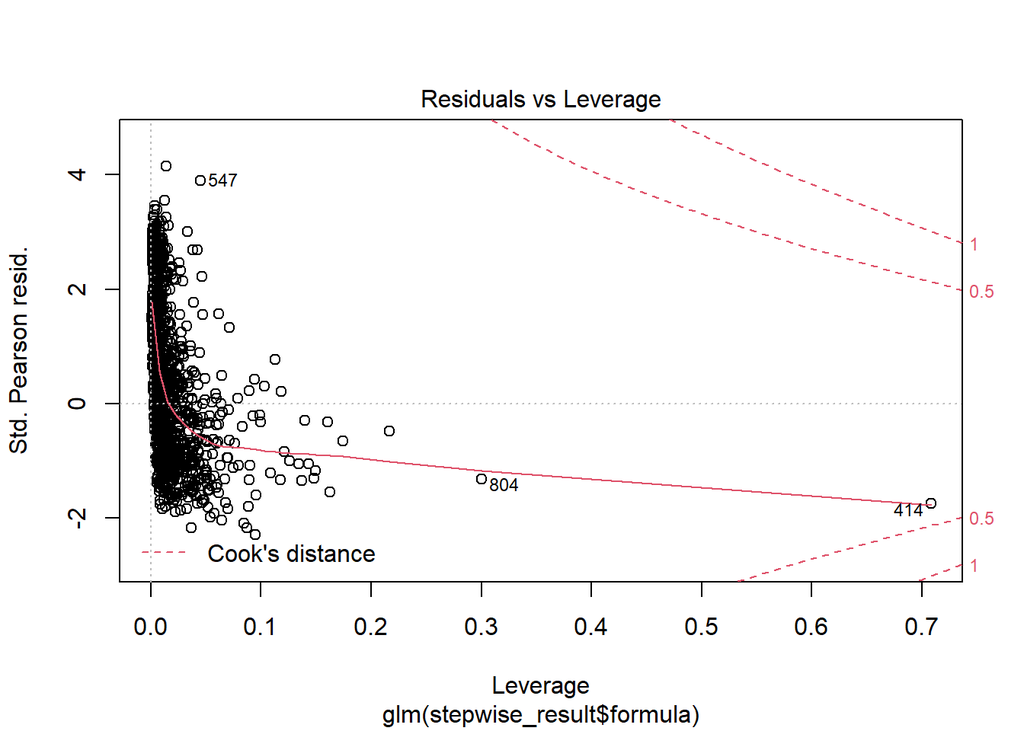

```r
plot(final_glm)
```

## Task 8 - Fit a LASSO

```r
#THE ONLY CHANGES NEEDED
#1. Replace "WEIGHT_VARIABLE" with the weight variable that you used for the GLM
#2. In the  "lasso_formula" below, use your formula from task 6
#3. Use the same FAMILY from task 6.  Type ?glmnet into the console to read the possible options

lasso_formula <- applicants ~ . + offset(log(num_units)) - neighborhood_n_ames - garage_type_attchd - num_units - log_sale_price

lasso_x_train <- model.matrix(lasso_formula, data = train)
lasso_x_test <- model.matrix(lasso_formula, data = test)

control <-trainControl(method="cv", number=15)
lassoGrid <- expand.grid(alpha = 1, lambda = seq(0.0001,0.01,by = 0.0005))

#Fit a lasso and inspect the variables which have zero coefficients.
#Note that the glmnet library only allows the identity link function
lasso <- train(x = lasso_x_train,
               y = train_y,
               method = 'glmnet',
               family = "poisson",

               trControl = control,
               tuneGrid = lassoGrid)

#This code gets the coefficients from the LASSO which are zero
lasso_results <- varImp(lasso,scale=F)
lasso_coefficients <- lasso_results$importance

#Show the coefficients which are zero
variables_with_zeros <- colnames(lasso_x_train)[which(lasso_coefficients$Overall==0)]
print("Variables with Coefficients of Zero:")
```

```
## [1] "Variables with Coefficients of Zero:"
```

```r
cat( paste( variables_with_zeros, collapse='\n' ) )
```

```
## year_sold
## tot_bathrooms
## neighborhood_gilbert
```

## Task 9 - Create a bagged tree model

The following code creates eight samples of the data. 20% of records are taken, with replacement, from the data randomly.

```r
sample1 <- train %>% sample_frac(0.2,replace=T)
sample2 <- train %>% sample_frac(0.2,replace=T)
sample3 <- train %>% sample_frac(0.2,replace=T)
sample4 <- train %>% sample_frac(0.2,replace=T)
sample5 <- train %>% sample_frac(0.2,replace=T)
sample6 <- train %>% sample_frac(0.2,replace=T)
sample7 <- train %>% sample_frac(0.2,replace=T)
sample8 <- train %>% sample_frac(0.2,replace=T)
```

This is the setting for the decision tree paramters. Make your adjustments here to test out different paramters.

```r
#ctrl <- rpart.control(minbucket = 5, cp = 0.01, maxdepth = 5)
ctrl <- rpart.control(minbucket = 10, cp = 0.001, maxdepth = 5)
#ctrl <- rpart.control(minbucket = 10, cp = 0.01, maxdepth = 7)
```

The following code sets up a decision tree using all the variables in the dataframe. Each tree uses only 20% of the records. The number of units are used as the weights.

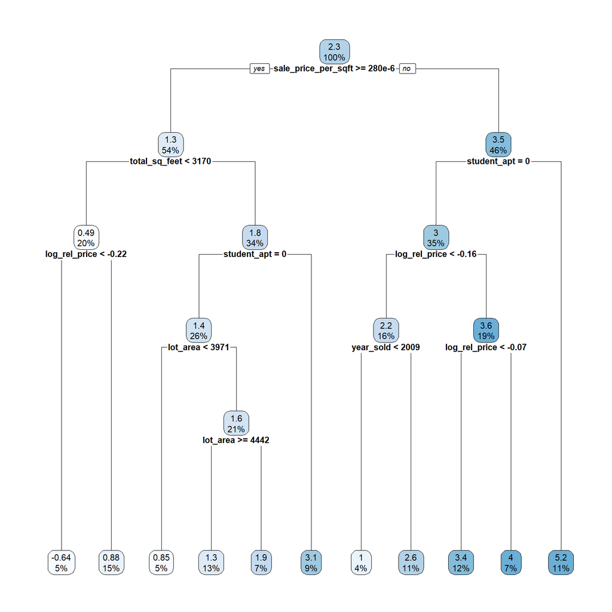

```r
tree1 <- rpart(data = sample1, lasso_formula, weights = sample1$num_units, control = ctrl)
tree2 <- rpart(data = sample2, lasso_formula, weights = sample2$num_units, control = ctrl)
tree3 <- rpart(data = sample3, lasso_formula, weights = sample3$num_units, control = ctrl)
tree4 <- rpart(data = sample4, lasso_formula, weights = sample4$num_units, control = ctrl)
tree5 <- rpart(data = sample5, lasso_formula, weights = sample5$num_units, control = ctrl)
tree6 <- rpart(data = sample6, lasso_formula, weights = sample6$num_units, control = ctrl)
tree7 <- rpart(data = sample7, lasso_formula, weights = sample7$num_units, control = ctrl)
tree8 <- rpart(data = sample8, lasso_formula, weights = sample8$num_units, control = ctrl)

rpart.plot(tree1, cex = .7)
```

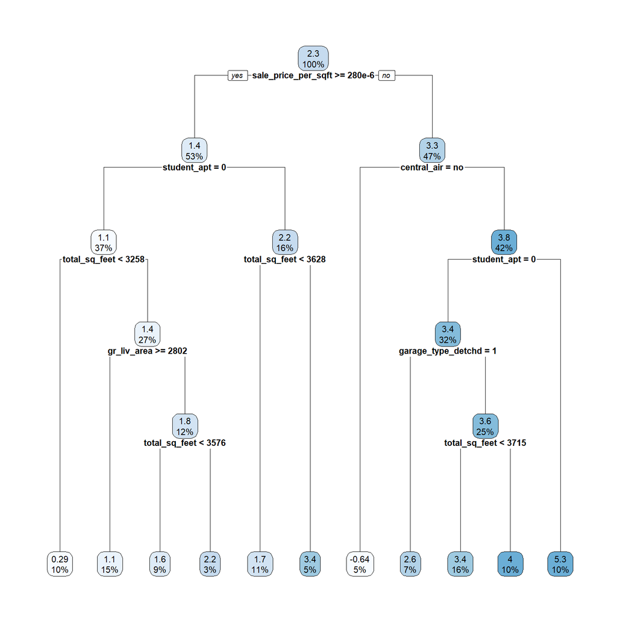

```r
rpart.plot(tree2, cex = .7)
```

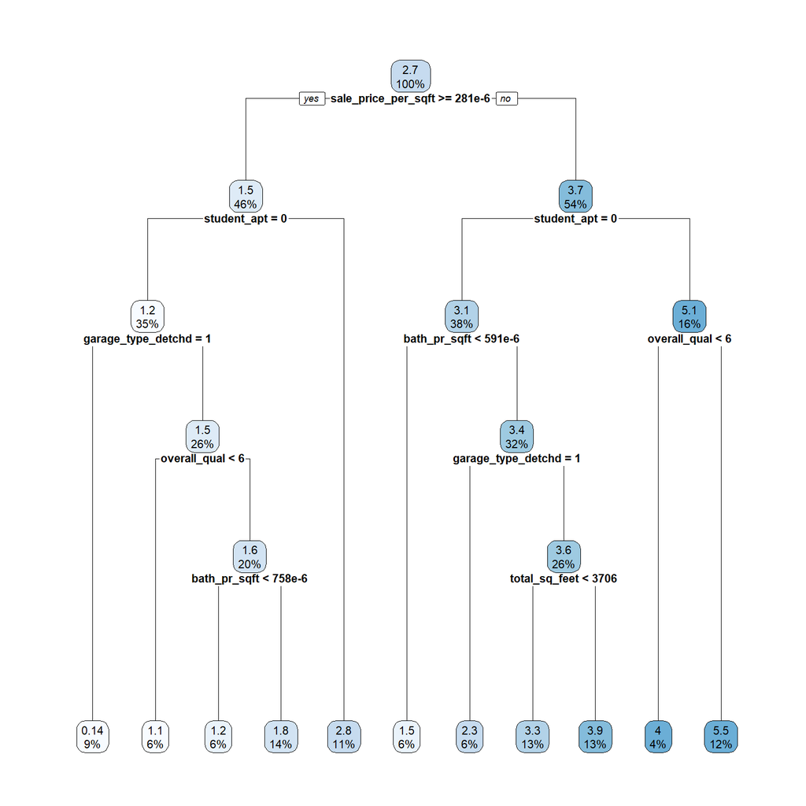

```r
rpart.plot(tree3, cex = .7)
```

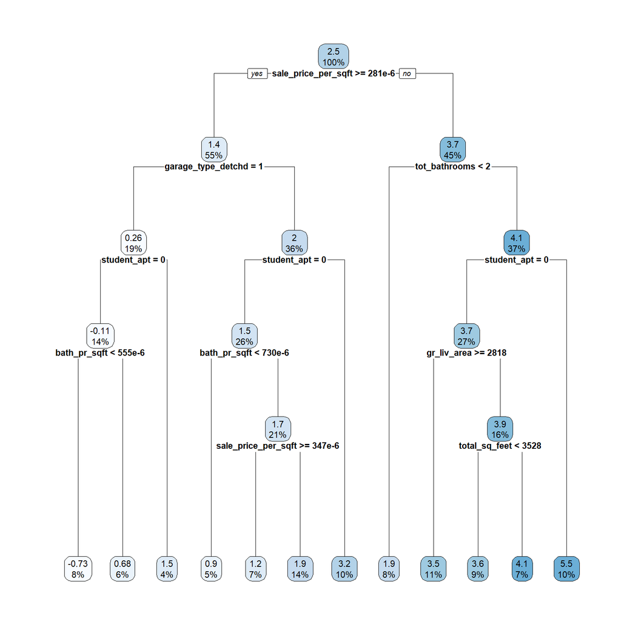

```r
rpart.plot(tree4, cex = .7)
```

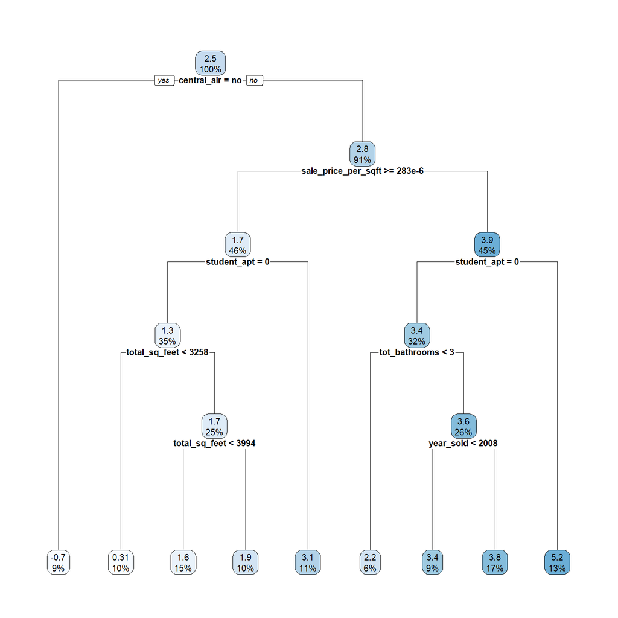

```r
rpart.plot(tree5, cex = .7)
```

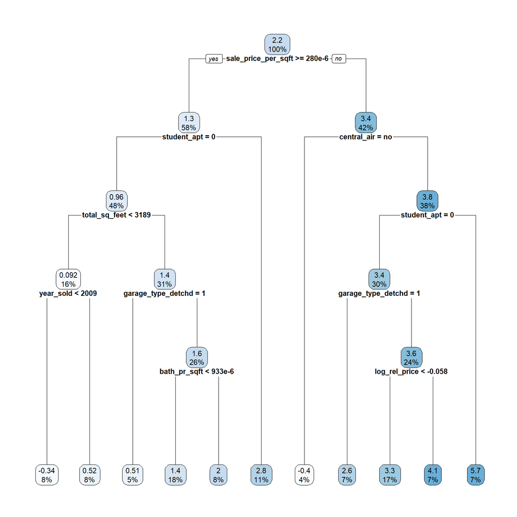

```r
rpart.plot(tree6, cex = .7)
```

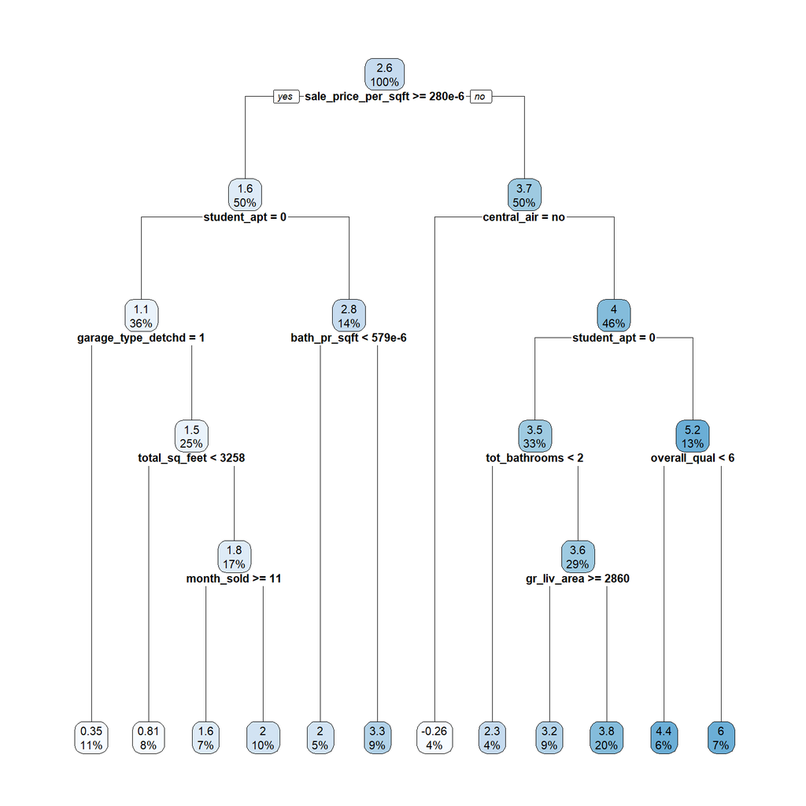

```r
rpart.plot(tree7, cex = .7)
```

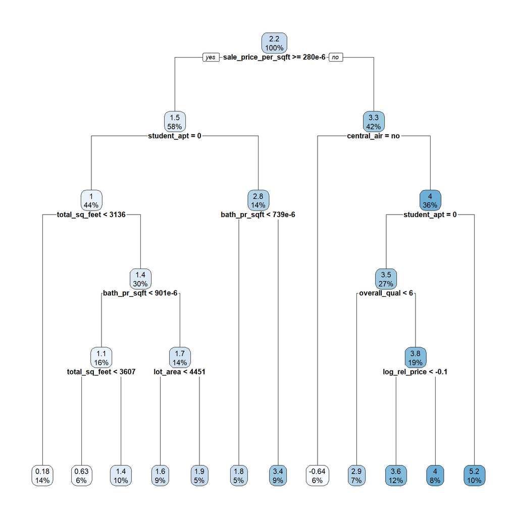

```r
rpart.plot(tree8, cex = .7)
```

```r
#make predictions
tree1_pred <- predict(tree1, newdata = test, type = "vector")
tree2_pred <- predict(tree2, newdata = test, type = "vector")
tree3_pred <- predict(tree3, newdata = test, type = "vector")
tree4_pred <- predict(tree4, newdata = test, type = "vector")
tree5_pred <- predict(tree5, newdata = test, type = "vector")
tree6_pred <- predict(tree6, newdata = test, type = "vector")
tree7_pred <- predict(tree7, newdata = test, type = "vector")
tree8_pred <- predict(tree8, newdata = test, type = "vector")

#UPDATE THIS FORMULA TO PERFORM BAGGING
trees_pred <- (tree1_pred + tree2_pred + tree3_pred+ tree4_pred+ tree5_pred+ tree6_pred+ tree7_pred+ tree8_pred)/8

LLfunction <- function(targets, predicted_values){
  p_v_zero <- ifelse(predicted_values <= 0, 0, predicted_values)
  p_v_pos <- ifelse(predicted_values <= 0, 0.000001 ,predicted_values)
  return(sum(targets*log(p_v_pos)) - sum(p_v_zero))
}
# "targets" is a vector containing the actual values for the target variable
# "predicted_values" is a vector containing the predicted values for the target variable

LLfunction(test$applicants, trees_pred)
```

```
## [1] 356.8725
```

```r
LLfunction(test$applicants, tree1_pred)
```

```
## [1] 128.2909
```

## Task 10 - Measure the variable importance with a Random Forest

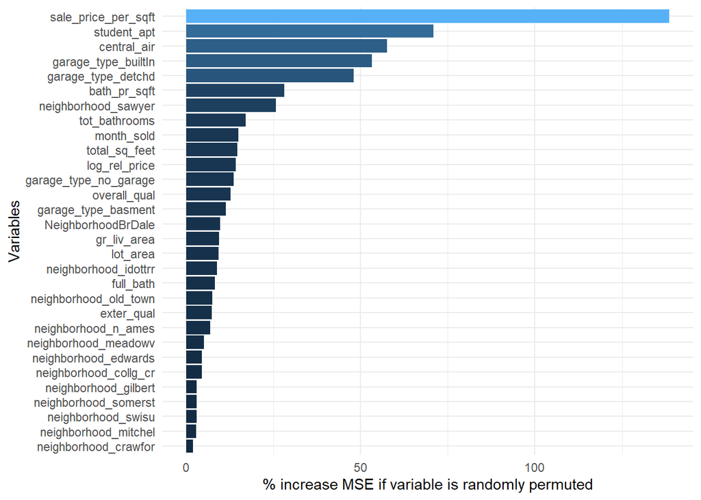

```r
#NO CHANGES NEEDED
RF <- randomForest( applicants ~ . + neighborhood_n_ames - garage_type_attchd - num_units - log_sale_price,
                   data = train,
                   weights = train_number_of_units,
                   ntree=400,
                   importance=TRUE)

imp_RF <- importance(RF)
imp_DF <- data.frame(Variables = row.names(imp_RF), MSE = imp_RF[,1])
imp_DF <- imp_DF[order(imp_DF$MSE, decreasing = TRUE),]

ggplot(imp_DF[1:30,], aes(x=reorder(Variables, MSE), y=MSE, fill=MSE)) + geom_bar(stat = 'identity') + labs(x = 'Variables', y= '% increase MSE if variable is randomly permuted') + coord_flip() + theme(legend.position="none")
```

## Task 11 - Compare model performance

```r
#This function will calculate the log-liklihood based on a Poisson model for the number of applicants
LLfunction <- function(targets, predicted_values){
  p_v_zero <- ifelse(predicted_values <= 0, 0, predicted_values)
  p_v_pos <- ifelse(predicted_values <= 0, 0.000001, predicted_values)
  return(sum(targets*log(p_v_pos)) - sum(p_v_zero))
}
print("loglikelihood")
```

```
## [1] "loglikelihood"
```

```r
glm_pred <- predict(final_glm, type="response", newdata = test)
lasso_pred <- exp(predict(lasso,newdata = lasso_x_test, weights = test_number_of_units))
RF_pred <- predict(RF, type="response", newdata = test)

tibble(Model = c("GLM", "LASSO", "Bagged Trees", "Random Forest"),
       LogLikelihood = c(LLfunction(test$applicants,glm_pred),
                         LLfunction(test$applicants,lasso_pred),
                         LLfunction(test$applicants, trees_pred),
                         LLfunction(test$applicants,RF_pred)))
```

```
## # A tibble: 4 x 2
##   Model         LogLikelihood
##   <chr>                 <dbl>
## 1 GLM                    236.
## 2 LASSO                  429.
## 3 Bagged Trees           357.
## 4 Random Forest          447.
```

## Task 12 - Executive Summary